# Schissler Final Project

# Group Bar Plot

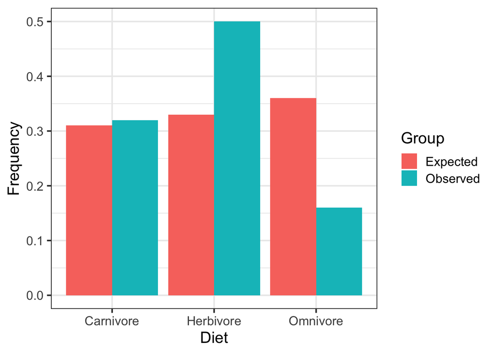

```r
library(ggplot2)
ggplot()+
geom_bar(data=mammalpropDATA, aes(x=Diet, y=frequency, fill=Group), stat="identity", position="dodge")+
theme_bw(base_size=16)+
ylab("Frequency")
```

**Figure 2.** Group Bar Graph comparing the frequency of each diet group (Carnivore, Omnivore, Herbivore) between the observed ADW data values and the expected ADW data values if the proportions matched the MammalDIET data proportions. Data provided by Animal Diversity Web and Kissling, W.D. et al.

## Conclusion

Despite the GLM’s significant results, the data did not meet the assumptions for normality and equal variance, which could affect the conclusions. The ADW dataset’s smaller sample size and non-representative nature, coupled with potential biases, highlight limitations. Future research should consider using more balanced datasets and exploring factors beyond body mass and diet, including predation and environmental influences. This study could inform conservation efforts and animal care practices by providing insights into factors affecting longevity, challenging media claims about weight and diet, and suggesting directions for broader research, including non-mammalian vertebrates and specific dietary components.

## Bibliography

Animal Diversity Web. Quaardvark. 2013. University of Michigan Museum of Zoology. https://animaldiversity.ummz.umich.edu/quaardvark/search/1E37C501-393E-0001-32B7-2A6014F113B8/?start=1.

Ebert T. 2008. Longevity and lack of senescence in the red sea urchin Strongylocentrotus franciscanus. Exp Gerontol: 43(8):734-8.

Kissling WD, Dalby L, Fløjgaard C, Lenoir J, Sandel B, Sandom C, Trøjelsgaard K, Svenning J-C. 2014. Establishing macroecological trait datasets: digitalization, extrapolation, and validation of diet preferences in terrestrial mammals worldwide. Dryad Digital Repository. doi: 10.5061/dryad.6cd0v. Price S, Hopkins S. 2015. The macroevolutionary relationship between diet and body mass across mammals. Biological Journal of the Linnean Society: 115(1):173–184. https://doi.org/10.1111/bij.12495.

Speakman J. 2005. Body size, energy metabolism and lifespan. Lifespan, Reproduction And Ecology. J Exp Biol 208 (9): 1717–1730.

Wilder M, Le Couteur D, Simpson S. 2013. Diet mediates the relationship between longevity and reproduction in mammals. Age (Dordr),: 35(3): 921–927.